# Complete: Infer ASVs with DADA2

Maya Craig

April 30, 2024

## Set seed

```r
set.seed(4750)
```

```r
# What time did we start running this script?
start_time <- Sys.time()
start_time
```

```
## [1] "2024-04-30 19:13:04 EDT"
```

# Goals of this file

1. Use raw fastq files and generate quality plots to assess quality of reads.
2. Filter and trim out bad sequences and bases from our sequencing files.
3. Write out fastq files with high quality sequences.
4. Evaluate the quality from our filter and trim.
5. Infer Errors on forward and reverse reads individually.
6. Identified ASVs on forward and reverse reads separately, using the error model.
7. Merge forward and reverse ASVs into “contiguous ASVs”.
8. Generate the ASV count table. (`otu_table` input for phyloseq.).

# Load packages

```r
# Use this to install the most recent version of patchwork (otherwise the aggregated plot functions will not work)
#devtools::install_github("thomasp85/patchwork@HEAD")
# Efficient package loading with pacman
pacman::p_load(tidyverse, BiocManager, devtools, dada2,
               phyloseq, patchwork, DT, iNEXT, vegan,
               install = FALSE)
library(ggplot2)
```

# Load data

```r
# Set the raw fastq path to the raw sequencing files
# Path to the fastq files
raw_fastqs_path <- "data/01_raw_gzipped_fastqs"
raw_fastqs_path
```

```
## [1] "data/01_raw_gzipped_fastqs"
```

```r
head(list.files(raw_fastqs_path))
```

```
## [1] "SRR23008984_1.fastq.gz" "SRR23008984_2.fastq.gz" "SRR23008985_1.fastq.gz"
## [4] "SRR23008985_2.fastq.gz" "SRR23008986_1.fastq.gz" "SRR23008986_2.fastq.gz"
```

```r
str(list.files(raw_fastqs_path)) #how many files
```

```
##  chr [1:94] "SRR23008984_1.fastq.gz" "SRR23008984_2.fastq.gz" ...
```

# Create vector of forward reads

```r
forward_reads <- list.files(raw_fastqs_path, pattern = "_1.fastq.gz", full.names = TRUE)

#Intuition check
head(forward_reads)
```

```
## [1] "data/01_raw_gzipped_fastqs/SRR23008984_1.fastq.gz"
## [2] "data/01_raw_gzipped_fastqs/SRR23008985_1.fastq.gz"
## [3] "data/01_raw_gzipped_fastqs/SRR23008986_1.fastq.gz"
## [4] "data/01_raw_gzipped_fastqs/SRR23008987_1.fastq.gz"
## [5] "data/01_raw_gzipped_fastqs/SRR23008988_1.fastq.gz"
## [6] "data/01_raw_gzipped_fastqs/SRR23008989_1.fastq.gz"
```

# Create vector of reverse reads

```r
reverse_reads <- list.files(raw_fastqs_path, pattern = "_2.fastq.gz", full.names = TRUE)
head(reverse_reads)
```

```
## [1] "data/01_raw_gzipped_fastqs/SRR23008984_2.fastq.gz"
## [2] "data/01_raw_gzipped_fastqs/SRR23008985_2.fastq.gz"
## [3] "data/01_raw_gzipped_fastqs/SRR23008986_2.fastq.gz"
## [4] "data/01_raw_gzipped_fastqs/SRR23008987_2.fastq.gz"
## [5] "data/01_raw_gzipped_fastqs/SRR23008988_2.fastq.gz"
## [6] "data/01_raw_gzipped_fastqs/SRR23008989_2.fastq.gz"
```

# Asses Read Quality

## Evaluate raw read sequence quality

- Examining the quality of reads before trimming

```r
# Randomly select 12 samples from dataset to evaluate the quality
random_samples <- sample(1:length(reverse_reads), size = 12)
random_samples
```

```
##  [1]  5 24 36 41  1 20 30 38 35  4 11 17
```

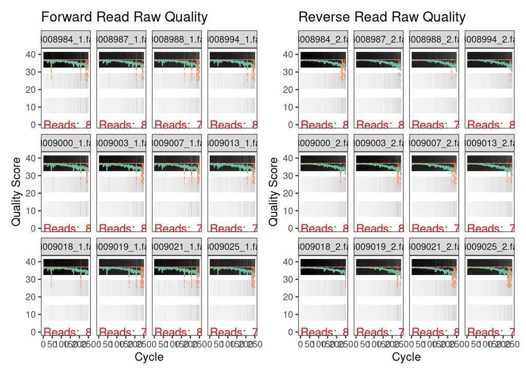

```r
# Calculate and plot quality of these twelve samples (for forward and reverse reads)
forward_filteredQual_plot_12 <- plotQualityProfile(forward_reads[random_samples]) +
  labs(title = "Forward Read Raw Quality")

reverse_filteredQual_plot_12 <- plotQualityProfile(reverse_reads[random_samples]) +
  labs(title = "Reverse Read Raw Quality")

preQC_aggregate_plot <- forward_filteredQual_plot_12 + reverse_filteredQual_plot_12

preQC_aggregate_plot #Note: make sure the patchwork and ggplot packages are up to date for this to run!
```

# Aggregate all QC plots

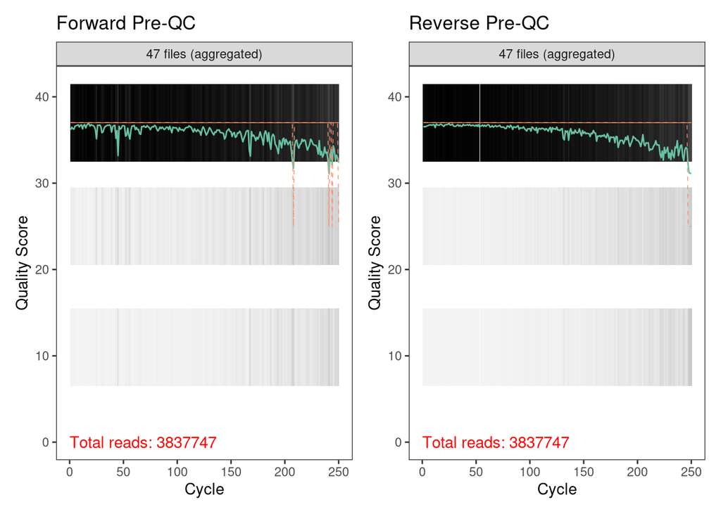

```r
# Forward reads
forward_preQC_plot <-
  plotQualityProfile(forward_reads, aggregate = TRUE) +
  labs(title = "Forward Pre-QC")

# reverse reads
reverse_preQC_plot <-
  plotQualityProfile(reverse_reads, aggregate = TRUE) +
  labs(title = "Reverse Pre-QC")

preQC_aggregate_plot <-
  # Plot the forward and reverse together
  forward_preQC_plot + reverse_preQC_plot

# Show the plot
preQC_aggregate_plot
```

**Interpretation:** Before the filtering in trimming, the quality score or the forward reads is between 30 and 40 for each cycle up until the 200th cycle. For the reverse reads, the quality score begins to decline a little before the 250th cycle. There is a total of 3837747 reads at this point.

## Prepare a placeholder for filtered reads

```r
# vector of our samples, extract sample name from files
samples <- sapply(strsplit(basename(forward_reads), "_"), `[`,1)
head(samples)
```

```
## [1] "SRR23008984" "SRR23008985" "SRR23008986" "SRR23008987" "SRR23008988"
## [6] "SRR23008989"
```

```r
# Place filtered reads into filtered_fastqs_path
filtered_fastqs_path <- "data/01_DADA2/02_filtered_fastqs"
filtered_fastqs_path
```

```
## [1] "data/01_DADA2/02_filtered_fastqs"
```

```r
# create 2 variables: filtered_F, filtered_R
filtered_forward_reads <-
  file.path(filtered_fastqs_path, paste0(samples, "_1_filtered.fastq.gz"))
length(filtered_forward_reads)
```

```
## [1] 47
```

```r
# reverse reads
filtered_reverse_reads <-
  file.path(filtered_fastqs_path, paste0(samples, "_2_filtered.fastq.gz"))

# Intuition check
head(filtered_reverse_reads)
```

```
## [1] "data/01_DADA2/02_filtered_fastqs/SRR23008984_2_filtered.fastq.gz"
## [2] "data/01_DADA2/02_filtered_fastqs/SRR23008985_2_filtered.fastq.gz"
## [3] "data/01_DADA2/02_filtered_fastqs/SRR23008986_2_filtered.fastq.gz"
## [4] "data/01_DADA2/02_filtered_fastqs/SRR23008987_2_filtered.fastq.gz"
## [5] "data/01_DADA2/02_filtered_fastqs/SRR23008988_2_filtered.fastq.gz"
## [6] "data/01_DADA2/02_filtered_fastqs/SRR23008989_2_filtered.fastq.gz"
```

# Filter and Trim Reads

- `maxEE` is a quality filtering threshold applied to expected errors. Here, if there’s 2 expected errors. It’s ok. But more than 2. Throw away the sequence. Two values, first is for forward reads; second is for reverse reads.
- `trimLeft` can be used to remove the beginning bases of a read (e.g. to trim out primers!)
- `truncLen` can be used to trim your sequences after a specific base pair when the quality gets lower. Though, please note that this will shorten the ASVs! For example, this can be used when the quality of the sequence suddenly gets lower, or clearly is typically lower. So, if the quality of the read drops below a phred score of 25 (on the y-axis of the plotQualityProfile above, which indicates ~99.5% confidence per base).
- `maxN` the number of N bases. Here, using ASVs, we should ALWAYS remove all Ns from the data.

```r
# Assign a vector to filtered reads
# write out filtered fastq files
# Therefore, we do not need to trim the primers, because they were not sequenced
filtered_reads <-
  filterAndTrim(fwd = forward_reads, filt = filtered_forward_reads,
              rev = reverse_reads, filt.rev = filtered_reverse_reads, truncLen=c(250,225),
              maxN = 0, maxEE = c(2,2), trimLeft = c(19,20),
              truncQ = 2, rm.phix = TRUE, compress = TRUE, multithread = TRUE)
head(filtered_reads)
```

```
##                        reads.in reads.out
## SRR23008984_1.fastq.gz    87951     81056
## SRR23008985_1.fastq.gz    78062     71068
## SRR23008986_1.fastq.gz    75730     69952
## SRR23008987_1.fastq.gz    81827     75996
## SRR23008988_1.fastq.gz    76777     71616
## SRR23008989_1.fastq.gz    74179     68198
```

# Plot the 12 random samples after QC

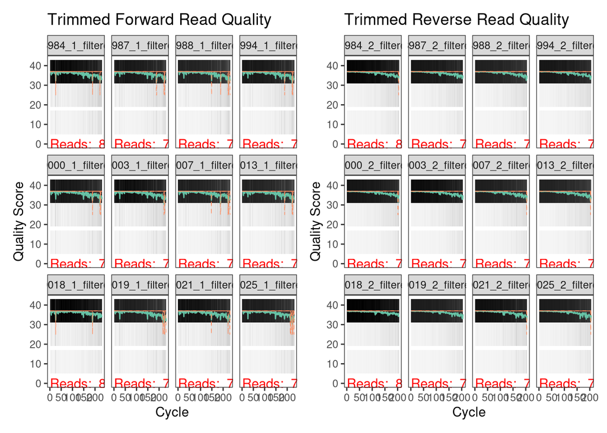

```r
forward_filteredQual_plot_12 <-
  plotQualityProfile(filtered_forward_reads[random_samples]) +
  labs(title = "Trimmed Forward Read Quality")

reverse_filteredQual_plot_12 <-
  plotQualityProfile(filtered_reverse_reads[random_samples]) +
  labs(title = "Trimmed Reverse Read Quality")

# Put the two plots together
QC_aggregate_plot <- forward_filteredQual_plot_12 + reverse_filteredQual_plot_12
QC_aggregate_plot
```

## Aggregated Trimmed Plots

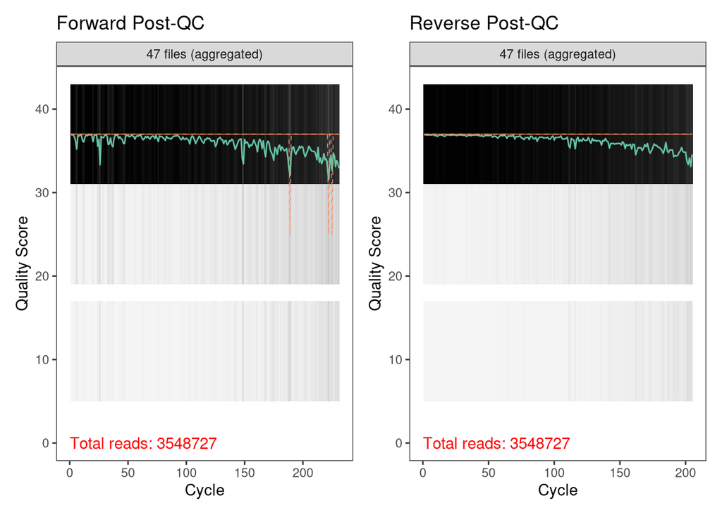

```r
# Forward reads
forward_postQC_plot <-
  plotQualityProfile(filtered_forward_reads, aggregate = TRUE) +
  labs(title = "Forward Post-QC")

# reverse reads
reverse_postQC_plot <-
  plotQualityProfile(filtered_reverse_reads, aggregate = TRUE) +
  labs(title = "Reverse Post-QC")

postQC_aggregate_plot <-
  forward_postQC_plot + reverse_postQC_plot

# Show the plot
postQC_aggregate_plot
```

**Interpretation of trimmed plots**: The quality of both the forward and reverse read seems to have improved after filtering and trimming. For both the forward and reverse, the read quality is between 30-40.

```r
# Make output into dataframe
filtered_df <- as.data.frame(filtered_reads)
head(filtered_df)
```

```
##                        reads.in reads.out
## SRR23008984_1.fastq.gz    87951     81056
## SRR23008985_1.fastq.gz    78062     71068
## SRR23008986_1.fastq.gz    75730     69952
## SRR23008987_1.fastq.gz    81827     75996
## SRR23008988_1.fastq.gz    76777     71616
## SRR23008989_1.fastq.gz    74179     68198
```

```r
# calculate some stats
filtered_df %>%
  reframe(median_reads_in = median(reads.in),
          median_reads_out = median(reads.out),
          median_percent_retained = (median(reads.out)/median(reads.in)))
```

```
##   median_reads_in median_reads_out median_percent_retained
## 1           81827            75805               0.9264057
```

**Interpretation**: The median percent of retained reads is about 93%. There was a median of 81827 reads before quality control, and there was a median of 75805 reads after QC. This tells me that the vast majority of reads had a quality score between 30 and 40.

### Visualize QC differences in plot

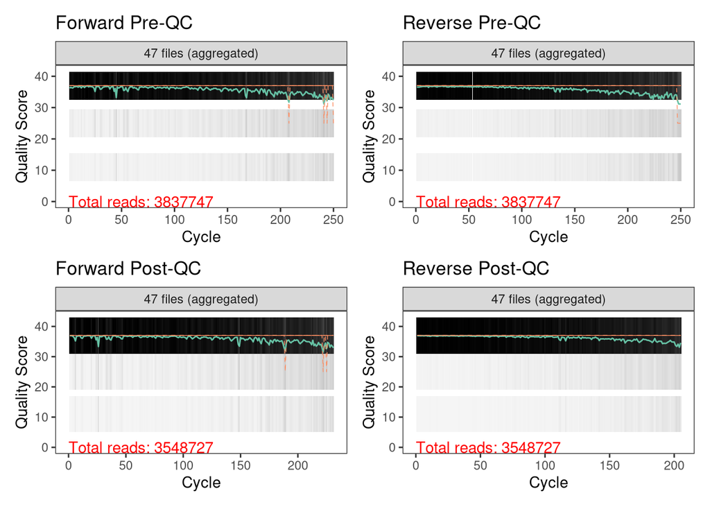

```r
# Plot the pre and post together in one plot
preQC_aggregate_plot / postQC_aggregate_plot
```

# Learn Errors

```r
# Forward reads
error_forward_reads <-
  learnErrors(filtered_forward_reads, multithread = TRUE)
```

```
## 101151666 total bases in 437886 reads from 6 samples will be used for learning the error rates.
```

```r
# Plot Forward
forward_error_plot <-
  plotErrors(error_forward_reads, nominalQ = TRUE) +
  labs(title = "Forward Read Error Model")

# Reverse reads
error_reverse_reads <-
  learnErrors(filtered_reverse_reads, multithread = TRUE)
```

```
## 104371035 total bases in 509127 reads from 7 samples will be used for learning the error rates.
```

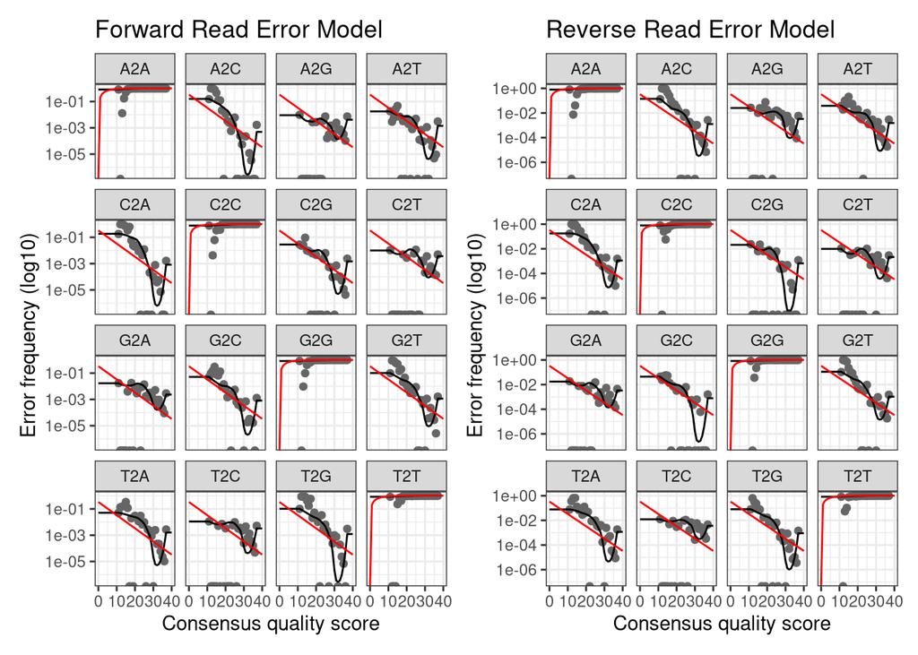

```r
# Plot reverse
reverse_error_plot <-
  plotErrors(error_reverse_reads, nominalQ = TRUE) +
  labs(title = "Reverse Read Error Model")

# Put the two plots together
forward_error_plot + reverse_error_plot
```

**Interpretation:** It looks like the errors are a reasonable fit to the observed reads. The error rate decreases as quality increases, which makes sense.

# Infer ASVs

```r
# Infer ASVs on the forward sequences
dada_forward <- dada(filtered_forward_reads,
                     err = error_forward_reads,
                     multithread = TRUE)
```

```
## Sample 1 - 81056 reads in 28698 unique sequences.
## Sample 2 - 71068 reads in 23001 unique sequences.
## Sample 3 - 69952 reads in 23085 unique sequences.
## Sample 4 - 75996 reads in 23958 unique sequences.
## Sample 5 - 71616 reads in 26181 unique sequences.
## Sample 6 - 68198 reads in 28737 unique sequences.
## Sample 7 - 71241 reads in 25955 unique sequences.
## Sample 8 - 80240 reads in 12509 unique sequences.
## Sample 9 - 79250 reads in 15828 unique sequences.
## Sample 10 - 74213 reads in 25080 unique sequences.
## Sample 11 - 75805 reads in 31299 unique sequences.
## Sample 12 - 75919 reads in 26129 unique sequences.
## Sample 13 - 81595 reads in 28266 unique sequences.
## Sample 14 - 76680 reads in 21889 unique sequences.
## Sample 15 - 78862 reads in 19273 unique sequences.
## Sample 16 - 80583 reads in 27464 unique sequences.
## Sample 17 - 76337 reads in 21861 unique sequences.
## Sample 18 - 72101 reads in 24330 unique sequences.
## Sample 19 - 74989 reads in 28895 unique sequences.
## Sample 20 - 79422 reads in 26232 unique sequences.
## Sample 21 - 78959 reads in 27408 unique sequences.
## Sample 22 - 80316 reads in 17261 unique sequences.
## Sample 23 - 65526 reads in 24468 unique sequences.
## Sample 24 - 72502 reads in 25687 unique sequences.
## Sample 25 - 70578 reads in 22941 unique sequences.
## Sample 26 - 70824 reads in 24201 unique sequences.
## Sample 27 - 71450 reads in 24550 unique sequences.
## Sample 28 - 79951 reads in 28969 unique sequences.
## Sample 29 - 70077 reads in 25270 unique sequences.
## Sample 30 - 71026 reads in 25472 unique sequences.
## Sample 31 - 75393 reads in 25196 unique sequences.
## Sample 32 - 74530 reads in 13425 unique sequences.
## Sample 33 - 75250 reads in 16454 unique sequences.
## Sample 34 - 74617 reads in 26548 unique sequences.
## Sample 35 - 82006 reads in 18476 unique sequences.
## Sample 36 - 73271 reads in 23847 unique sequences.
## Sample 37 - 65470 reads in 23085 unique sequences.
## Sample 38 - 78484 reads in 25686 unique sequences.
## Sample 39 - 80794 reads in 24731 unique sequences.
## Sample 40 - 80402 reads in 14763 unique sequences.
## Sample 41 - 73584 reads in 22708 unique sequences.
## Sample 42 - 78281 reads in 24643 unique sequences.
## Sample 43 - 83411 reads in 27245 unique sequences.
## Sample 44 - 81003 reads in 12729 unique sequences.
## Sample 45 - 76236 reads in 27348 unique sequences.
## Sample 46 - 72468 reads in 15455 unique sequences.
## Sample 47 - 77195 reads in 18356 unique sequences.
```

```r
typeof(dada_forward)
```

```
## [1] "list"
```

```r
# Grab a sample and look at it
dada_forward$SRR23008984_1_filtered.fastq.gz
```

```
## dada-class: object describing DADA2 denoising results
## 489 sequence variants were inferred from 28698 input unique sequences.
## Key parameters: OMEGA_A = 1e-40, OMEGA_C = 1e-40, BAND_SIZE = 16
```

```r
# Infer ASVs on the reverse sequences
dada_reverse <- dada(filtered_reverse_reads,
                     err = error_reverse_reads,
                     multithread = TRUE)
```

```
## Sample 1 - 81056 reads in 20820 unique sequences.
## Sample 2 - 71068 reads in 17116 unique sequences.
## Sample 3 - 69952 reads in 16325 unique sequences.
## Sample 4 - 75996 reads in 17511 unique sequences.
## Sample 5 - 71616 reads in 18897 unique sequences.
## Sample 6 - 68198 reads in 19181 unique sequences.
## Sample 7 - 71241 reads in 18882 unique sequences.
## Sample 8 - 80240 reads in 9455 unique sequences.
## Sample 9 - 79250 reads in 12593 unique sequences.
## Sample 10 - 74213 reads in 19120 unique sequences.
## Sample 11 - 75805 reads in 23556 unique sequences.
## Sample 12 - 75919 reads in 18950 unique sequences.
## Sample 13 - 81595 reads in 20465 unique sequences.
## Sample 14 - 76680 reads in 15690 unique sequences.
## Sample 15 - 78862 reads in 15930 unique sequences.
## Sample 16 - 80583 reads in 20036 unique sequences.
## Sample 17 - 76337 reads in 15253 unique sequences.
## Sample 18 - 72101 reads in 17217 unique sequences.
## Sample 19 - 74989 reads in 21252 unique sequences.
## Sample 20 - 79422 reads in 18523 unique sequences.
## Sample 21 - 78959 reads in 19700 unique sequences.
## Sample 22 - 80316 reads in 14280 unique sequences.
## Sample 23 - 65526 reads in 16591 unique sequences.
## Sample 24 - 72502 reads in 19478 unique sequences.
## Sample 25 - 70578 reads in 15961 unique sequences.
## Sample 26 - 70824 reads in 17576 unique sequences.
## Sample 27 - 71450 reads in 17558 unique sequences.
## Sample 28 - 79951 reads in 20616 unique sequences.
## Sample 29 - 70077 reads in 18503 unique sequences.
## Sample 30 - 71026 reads in 19233 unique sequences.
## Sample 31 - 75393 reads in 19015 unique sequences.
## Sample 32 - 74530 reads in 10850 unique sequences.
## Sample 33 - 75250 reads in 13807 unique sequences.
## Sample 34 - 74617 reads in 18906 unique sequences.
## Sample 35 - 82006 reads in 15095 unique sequences.
## Sample 36 - 73271 reads in 16366 unique sequences.
## Sample 37 - 65470 reads in 16206 unique sequences.
## Sample 38 - 78484 reads in 18161 unique sequences.
## Sample 39 - 80794 reads in 16694 unique sequences.
## Sample 40 - 80402 reads in 11637 unique sequences.
## Sample 41 - 73584 reads in 16124 unique sequences.
## Sample 42 - 78281 reads in 15704 unique sequences.
## Sample 43 - 83411 reads in 19948 unique sequences.
## Sample 44 - 81003 reads in 9394 unique sequences.
## Sample 45 - 76236 reads in 18649 unique sequences.
## Sample 46 - 72468 reads in 11909 unique sequences.
## Sample 47 - 77195 reads in 13049 unique sequences.
```

```r
# Inspect
dada_reverse[1]
```

```
## $SRR23008984_2_filtered.fastq.gz
## dada-class: object describing DADA2 denoising results
## 563 sequence variants were inferred from 20820 input unique sequences.
## Key parameters: OMEGA_A = 1e-40, OMEGA_C = 1e-40, BAND_SIZE = 16
```

```r
dada_reverse[30]
```

```
## $SRR23009013_2_filtered.fastq.gz
## dada-class: object describing DADA2 denoising results
## 747 sequence variants were inferred from 19233 input unique sequences.
## Key parameters: OMEGA_A = 1e-40, OMEGA_C = 1e-40, BAND_SIZE = 16
```

# Merge ASVs

- The result of the merge are contig sequences

```r
# merge forward and reverse ASVs
merged_ASVs <- mergePairs(dada_forward, filtered_forward_reads,
                          dada_reverse, filtered_reverse_reads,
                          verbose = TRUE)
```

```
## 75314 paired-reads (in 405 unique pairings) successfully merged out of 78224 (in 1167 pairings) input.
```

```
## 65711 paired-reads (in 419 unique pairings) successfully merged out of 68199 (in 1104 pairings) input.
```

```
## 65828 paired-reads (in 341 unique pairings) successfully merged out of 67895 (in 911 pairings) input.
```

```
## 70632 paired-reads (in 363 unique pairings) successfully merged out of 73811 (in 979 pairings) input.
```

```
## 65021 paired-reads (in 545 unique pairings) successfully merged out of 68637 (in 1257 pairings) input.
```

```
## 57316 paired-reads (in 719 unique pairings) successfully merged out of 63041 (in 1917 pairings) input.
```

```
## 62208 paired-reads (in 666 unique pairings) successfully merged out of 66270 (in 1655 pairings) input.
```

```
## 78409 paired-reads (in 205 unique pairings) successfully merged out of 79488 (in 424 pairings) input.
```

```
## 75773 paired-reads (in 348 unique pairings) successfully merged out of 77510 (in 892 pairings) input.
```

```
## 69708 paired-reads (in 353 unique pairings) successfully merged out of 71981 (in 886 pairings) input.
```

```
## 68967 paired-reads (in 689 unique pairings) successfully merged out of 72167 (in 1458 pairings) input.
```

```
## 70956 paired-reads (in 403 unique pairings) successfully merged out of 73492 (in 1003 pairings) input.
```

```
## 76335 paired-reads (in 427 unique pairings) successfully merged out of 79034 (in 1106 pairings) input.
```

```
## 71936 paired-reads (in 326 unique pairings) successfully merged out of 74490 (in 847 pairings) input.
```

```
## 73677 paired-reads (in 676 unique pairings) successfully merged out of 75881 (in 1297 pairings) input.
```

```
## 75423 paired-reads (in 524 unique pairings) successfully merged out of 77702 (in 1163 pairings) input.
```

```
## 74309 paired-reads (in 230 unique pairings) successfully merged out of 75467 (in 477 pairings) input.
```

```
## 68011 paired-reads (in 335 unique pairings) successfully merged out of 70441 (in 844 pairings) input.
```

```
## 70414 paired-reads (in 415 unique pairings) successfully merged out of 72774 (in 955 pairings) input.
```

```
## 74819 paired-reads (in 369 unique pairings) successfully merged out of 77405 (in 917 pairings) input.
```

```
## 74334 paired-reads (in 401 unique pairings) successfully merged out of 76586 (in 926 pairings) input.
```

```
## 74773 paired-reads (in 675 unique pairings) successfully merged out of 77163 (in 1385 pairings) input.
```

```
## 61938 paired-reads (in 275 unique pairings) successfully merged out of 63888 (in 702 pairings) input.
```

```
## 67464 paired-reads (in 407 unique pairings) successfully merged out of 69849 (in 1072 pairings) input.
```

```
## 65684 paired-reads (in 394 unique pairings) successfully merged out of 68097 (in 993 pairings) input.
```

```
## 65405 paired-reads (in 427 unique pairings) successfully merged out of 67824 (in 1091 pairings) input.
```

```
## 66436 paired-reads (in 517 unique pairings) successfully merged out of 68844 (in 1045 pairings) input.
```

```
## 75110 paired-reads (in 368 unique pairings) successfully merged out of 77561 (in 983 pairings) input.
```

```
## 65598 paired-reads (in 335 unique pairings) successfully merged out of 68003 (in 929 pairings) input.
```

```
## 63426 paired-reads (in 559 unique pairings) successfully merged out of 67636 (in 1383 pairings) input.
```

```
## 68521 paired-reads (in 357 unique pairings) successfully merged out of 72831 (in 868 pairings) input.
```

```
## 71659 paired-reads (in 391 unique pairings) successfully merged out of 73053 (in 776 pairings) input.
```

```
## 71329 paired-reads (in 426 unique pairings) successfully merged out of 72949 (in 897 pairings) input.
```

```
## 69757 paired-reads (in 378 unique pairings) successfully merged out of 72266 (in 1095 pairings) input.
```

```
## 77047 paired-reads (in 665 unique pairings) successfully merged out of 79306 (in 1368 pairings) input.
```

```
## 68725 paired-reads (in 438 unique pairings) successfully merged out of 70840 (in 1029 pairings) input.
```

```
## 60592 paired-reads (in 431 unique pairings) successfully merged out of 62811 (in 1023 pairings) input.
```

```
## 72773 paired-reads (in 441 unique pairings) successfully merged out of 75513 (in 1114 pairings) input.
```

```
## 77177 paired-reads (in 324 unique pairings) successfully merged out of 79255 (in 791 pairings) input.
```

```
## 78150 paired-reads (in 355 unique pairings) successfully merged out of 79193 (in 671 pairings) input.
```

```
## 70350 paired-reads (in 309 unique pairings) successfully merged out of 72040 (in 765 pairings) input.
```

```
## 74991 paired-reads (in 249 unique pairings) successfully merged out of 77026 (in 618 pairings) input.
```

```
## 77622 paired-reads (in 489 unique pairings) successfully merged out of 80384 (in 1307 pairings) input.
```

```
## 78885 paired-reads (in 332 unique pairings) successfully merged out of 79953 (in 642 pairings) input.
```

```
## 72542 paired-reads (in 278 unique pairings) successfully merged out of 74672 (in 762 pairings) input.
```

```
## 69281 paired-reads (in 446 unique pairings) successfully merged out of 70784 (in 919 pairings) input.
```

```
## 74649 paired-reads (in 235 unique pairings) successfully merged out of 75747 (in 493 pairings) input.
```

```r
# Evaluate the output
typeof(merged_ASVs)
```

```
## [1] "list"
```

```r
length(merged_ASVs)
```

```
## [1] 47
```

```r
names(merged_ASVs)
```

```
##  [1] "SRR23008984_1_filtered.fastq.gz" "SRR23008985_1_filtered.fastq.gz"
##  [3] "SRR23008986_1_filtered.fastq.gz" "SRR23008987_1_filtered.fastq.gz"
##  [5] "SRR23008988_1_filtered.fastq.gz" "SRR23008989_1_filtered.fastq.gz"
##  [7] "SRR23008990_1_filtered.fastq.gz" "SRR23008991_1_filtered.fastq.gz"
##  [9] "SRR23008992_1_filtered.fastq.gz" "SRR23008993_1_filtered.fastq.gz"
## [11] "SRR23008994_1_filtered.fastq.gz" "SRR23008995_1_filtered.fastq.gz"
## [13] "SRR23008996_1_filtered.fastq.gz" "SRR23008997_1_filtered.fastq.gz"
## [15] "SRR23008998_1_filtered.fastq.gz" "SRR23008999_1_filtered.fastq.gz"
## [17] "SRR23009000_1_filtered.fastq.gz" "SRR23009001_1_filtered.fastq.gz"
## [19] "SRR23009002_1_filtered.fastq.gz" "SRR23009003_1_filtered.fastq.gz"
## [21] "SRR23009004_1_filtered.fastq.gz" "SRR23009005_1_filtered.fastq.gz"
## [23] "SRR23009006_1_filtered.fastq.gz" "SRR23009007_1_filtered.fastq.gz"
## [25] "SRR23009008_1_filtered.fastq.gz" "SRR23009009_1_filtered.fastq.gz"
## [27] "SRR23009010_1_filtered.fastq.gz" "SRR23009011_1_filtered.fastq.gz"
## [29] "SRR23009012_1_filtered.fastq.gz" "SRR23009013_1_filtered.fastq.gz"
## [31] "SRR23009014_1_filtered.fastq.gz" "SRR23009015_1_filtered.fastq.gz"
## [33] "SRR23009016_1_filtered.fastq.gz" "SRR23009017_1_filtered.fastq.gz"
## [35] "SRR23009018_1_filtered.fastq.gz" "SRR23009019_1_filtered.fastq.gz"
## [37] "SRR23009020_1_filtered.fastq.gz" "SRR23009021_1_filtered.fastq.gz"
## [39] "SRR23009023_1_filtered.fastq.gz" "SRR23009024_1_filtered.fastq.gz"
## [41] "SRR23009025_1_filtered.fastq.gz" "SRR23009026_1_filtered.fastq.gz"
## [43] "SRR23009027_1_filtered.fastq.gz" "SRR23009028_1_filtered.fastq.gz"
## [45] "SRR23009029_1_filtered.fastq.gz" "SRR23009030_1_filtered.fastq.gz"
## [47] "SRR23009031_1_filtered.fastq.gz"
```

```r
# Inspect the merger data.frame from the 20211005-MA-CWS1P
head(merged_ASVs[[2]])
```

```
##                                                                                                                                                                                                                                                                    sequence
## 1  CGGTAATACGTAGGTCCCGAGCGTTGTCCGGATTTATTGGGCGTAAAGCGAGCGCAGGCG…
## 2 CGGTAATACGGAGGATGCGAGCGTTATCCGGATTTATTGGGTTTAAAGGGAGCGCAGACG…
## 3 CGGTAATACGTAGGGGGCAAGCGTTATCCGGATTTACTGGGTGTAAAGGGAGCGTAGACG…
## 4 CGGTAATACGGAAGGTCCGGGCGTTATCCGGATTTATTGGGTTTAAAGGGAGCGTAGGCC…
## 5  CGGTAATACGTAGGCGGCAAGCGTTGTCCGGAATTATTGGGCGTAAAGGGAGCGCAGGCG…
## 6  CGGTAATACGTAGGGGGCTAGCGTTATCCGGATTTACTGGGCGTAAAGGGTGCGTAGGCG…
##   abundance forward reverse nmatch nmismatch nindel prefer accept
## 1      8953       1       1    172         0      0      1   TRUE
## 2      6065       2       2    171         0      0      2   TRUE
## 3      4030       3       3    171         0      0      2   TRUE
## 4      3353       4       4    171         0      0      2   TRUE
## 5      3013       5       5    172         0      0      2   TRUE
## 6      2738       6       6    172         0      0      2   TRUE
```

# Create RAW ASV count table

```r
# Create the ASV Count Table
raw_ASV_table <- makeSequenceTable(merged_ASVs)

# Write out the file to data/01_DADA2

# Check the type and dimensions of the data
dim(raw_ASV_table)
```

```
## [1]   47 8309
```

```r
class(raw_ASV_table)
```

```
## [1] "matrix" "array"
```

```r
typeof(raw_ASV_table)
```

```
## [1] "integer"
```

```r
# Inspect the distribution of sequence lengths of all ASVs in dataset
table(nchar(getSequences(raw_ASV_table)))
```

```
##
##  231  232  233  234  235  237  238  239  240  241  242  243  244  245  246  247
##   34    3    5    4    3    1    2    2    7    7    2    2    3    4    4    4
##  248  249  250  251  252  253  255  256  257  258  259  260  261  262  263  264
##    6    2    4    1    5    3    2    5  147    4    4    1    3   13   24 1396
##  265  266  267  268  269  271  272  273  274  275  276  277  278  280  281  282
## 5489  198   17    6    5    2    4    1    2    2    3    2    2    1    2    2
##  283  284  285  286  287  289  290  291  293  294  295  296  297  298  299  300
##    2    6    5    4    2    2    8    3    2    7    2    2    2    1    2    3
##  301  304  305  307  308  309  310  311  312  313  314  315  316  317  318  319
##    1    3    1    2    2    9   15   13    7    3   33   60  115   50   70   80
##  320  321  322  323  324  325  326  327  328  329  330  331  332  333  334  335
##   21   10    1    4   15   10   11    2    6    4    1    4   10   19   11    4
##  336  337  338  339  340  341  342  343  344  345  346  348  352  355  356  357
##    5    2    1    2    2    1    1    1    1    1    1    2    2    2    1    1
##  358  361  362  363  364  365  366  367  368  369  370  371  372  373  374  375
##    3    3    2    8    8   22    6   16    8   18    8    8    8    4    6    4
##  376  377  378  379  380  381  383  384  385  386  387  389  390  391  392  397
##    4    9    1    1    4    2    1    1    2    2    1    3    2    2    2    2
##  402  404  408  410  412  415  416  417  418  419  421  423
##    1    2    1    1    2    1    2    1    3    1    1    1
```

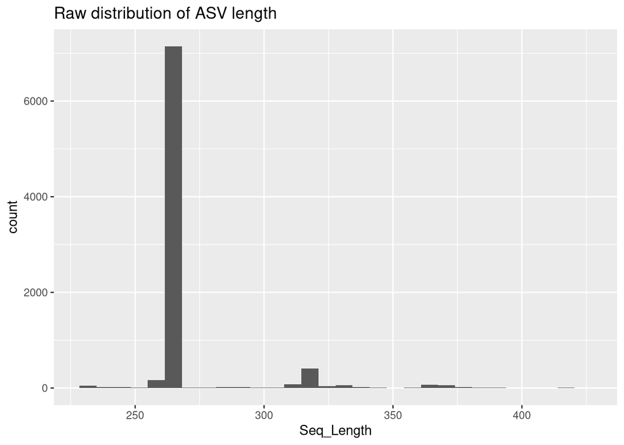

```r
# Inspect the distribution of sequence lengths of all ASVs in dataset
# AFTER TRIM
data.frame(Seq_Length = nchar(getSequences(raw_ASV_table))) %>%
  ggplot(aes(x = Seq_Length )) +
  geom_histogram() +
  labs(title = "Raw distribution of ASV length")
```

```r
# Create the ASV Count Table
raw_ASV_table <- makeSequenceTable(merged_ASVs)

# Write out the file to data/01_DADA2

###################################################
###################################################
# TRIM THE ASVS

# We will allow for a few
raw_ASV_table_trimmed <- raw_ASV_table[,nchar(colnames(raw_ASV_table))  %in% 264:265]

# Inspect the distribution of sequence lengths of all ASVs in dataset
table(nchar(getSequences(raw_ASV_table_trimmed)))
```

```
##
##  264  265
## 1396 5489
```

```r
# What proportion is left of the sequences?
sum(raw_ASV_table_trimmed)/sum(raw_ASV_table)
```

```
## [1] 0.9895581
```

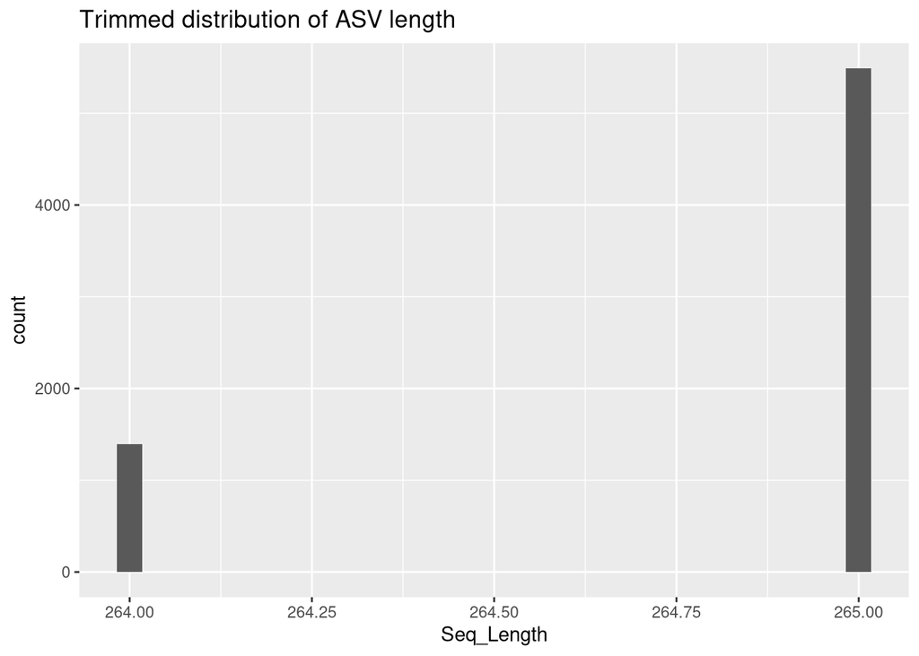

```r
# Inspect the distribution of sequence lengths of all ASVs in dataset
# AFTER TRIM
data.frame(Seq_Length = nchar(getSequences(raw_ASV_table_trimmed))) %>%
  ggplot(aes(x = Seq_Length )) +
  geom_histogram() +
  labs(title = "Trimmed distribution of ASV length")
```

[figure not shown]

```r
# Let's zoom in on the plot
data.frame(Seq_Length = nchar(getSequences(raw_ASV_table_trimmed))) %>%
  ggplot(aes(x = Seq_Length )) +
  geom_histogram() +
  labs(title = "Trimmed distribution of ASV length") +
  scale_y_continuous(limits = c(0, 500))
```

# Remove Chimeras

NOTE: Most of the reads should remain after the removal of chimeras

```r
# Remove the chimeras in the raw ASV table
noChimeras_ASV_table <- removeBimeraDenovo(raw_ASV_table_trimmed,
                                           method="consensus",
                                           multithread=TRUE, verbose=TRUE)
```

```
## Identified 1990 bimeras out of 6885 input sequences.
```

```r
# Check the dimensions
dim(noChimeras_ASV_table)
```

```
## [1]   47 4895
```

```r
# What proportion is left of the sequences?
sum(noChimeras_ASV_table)/sum(raw_ASV_table_trimmed)
```

```
## [1] 0.9589617
```

```r
sum(noChimeras_ASV_table)/sum(raw_ASV_table)
```

```
## [1] 0.9489483
```

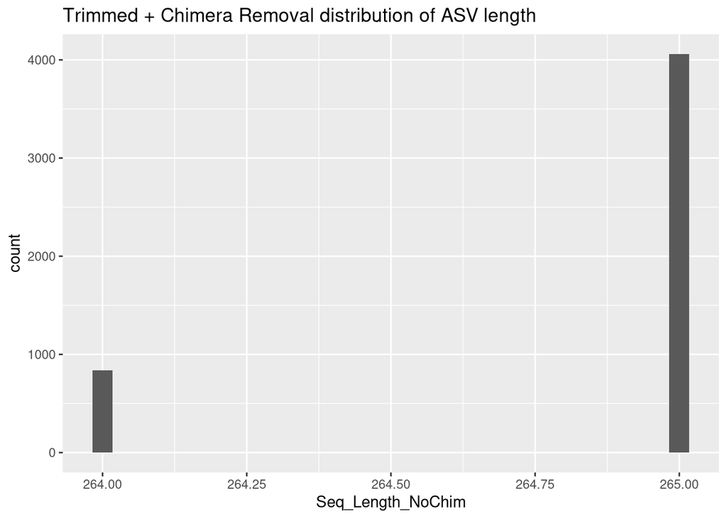

```r
# Plot it
data.frame(Seq_Length_NoChim = nchar(getSequences(noChimeras_ASV_table))) %>%
  ggplot(aes(x = Seq_Length_NoChim )) +
  geom_histogram()+
  labs(title = "Trimmed + Chimera Removal distribution of ASV length")
```

# Track read counts

```r
# make function to identify number of sequence
getN <- function(x) sum(getUniques(x))

# Make the table to track the seqs
track <- cbind(filtered_reads,
               sapply(dada_forward, getN),
               sapply(dada_reverse, getN),
               sapply(merged_ASVs, getN),
               rowSums(noChimeras_ASV_table))

head(track)
```

```
##                        reads.in reads.out
## SRR23008984_1.fastq.gz    87951     81056 79138 79358 75314 71252
## SRR23008985_1.fastq.gz    78062     71068 69040 69330 65711 61050
## SRR23008986_1.fastq.gz    75730     69952 68521 68657 65828 63098
## SRR23008987_1.fastq.gz    81827     75996 74494 74684 70632 68157
## SRR23008988_1.fastq.gz    76777     71616 69638 69720 65021 62121
## SRR23008989_1.fastq.gz    74179     68198 64261 65198 57316 53198
```

```r
# Update column names to be more informative (most are missing at the moment!)
colnames(track) <- c("input", "filtered", "denoisedF", "denoisedR", "merged", "nochim")
rownames(track) <- samples

# Generate a dataframe to track the reads through our DADA2 pipeline
track_counts_df <-
  track %>%
  # make it a dataframe
  as.data.frame() %>%
  rownames_to_column(var = "names") %>%
  mutate(perc_reads_retained = 100 * nochim / input)

# Visualize it in table format
DT::datatable(track_counts_df)
```

|  | names | input | filtered | denoisedF | denoisedR | merged | nochim | perc_reads_retained |
| --- | --- | --- | --- | --- | --- | --- | --- | --- |
| 1 | SRR23008984 | 87951 | 81056 | 79138 | 79358 | 75314 | 71252 | 81.01329149185342 |
| 2 | SRR23008985 | 78062 | 71068 | 69040 | 69330 | 65711 | 61050 | 78.20706617816607 |
| 3 | SRR23008986 | 75730 | 69952 | 68521 | 68657 | 65828 | 63098 | 83.31968836656543 |
| 4 | SRR23008987 | 81827 | 75996 | 74494 | 74684 | 70632 | 68157 | 83.29402275532526 |
| 5 | SRR23008988 | 76777 | 71616 | 69638 | 69720 | 65021 | 62121 | 80.91094989384843 |
| 6 | SRR23008989 | 74179 | 68198 | 64261 | 65198 | 57316 | 53198 | 71.71571469014141 |
| 7 | SRR23008990 | 77648 | 71241 | 67297 | 68323 | 62208 | 59065 | 76.06763857407789 |
| 8 | SRR23008991 | 85748 | 80240 | 79783 | 79765 | 78409 | 70344 | 82.03573261183935 |
| 9 | SRR23008992 | 85334 | 79250 | 78050 | 78190 | 75773 | 72455 | 84.90753978484543 |
| 10 | SRR23008993 | 80759 | 74213 | 72771 | 72786 | 69708 | 68053 | 84.2667690288389 |

[output cut: 37 more lines]

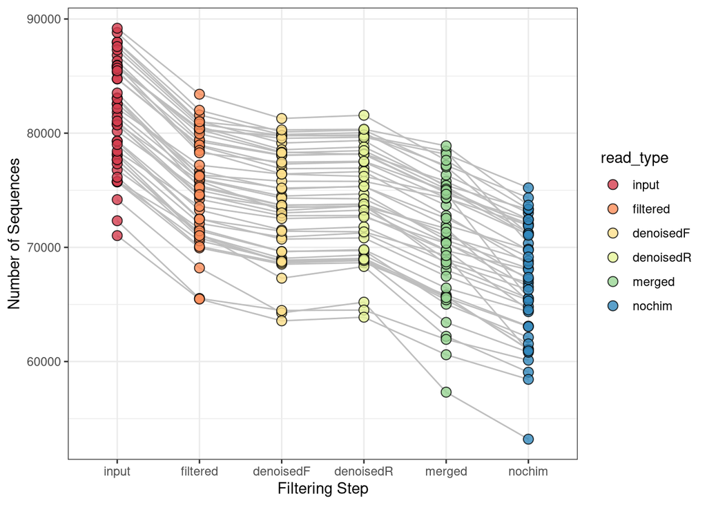

```r
# Plot it!
track_counts_df %>%
  pivot_longer(input:nochim, names_to = "read_type", values_to = "num_reads") %>%
  mutate(read_type = fct_relevel(read_type,
                                 "input", "filtered", "denoisedF", "denoisedR", "merged", "nochim")) %>%
  ggplot(aes(x = read_type, y = num_reads, fill = read_type)) +
  geom_line(aes(group = names), color = "grey") +
  geom_point(shape = 21, size = 3, alpha = 0.8) +
  scale_fill_brewer(palette = "Spectral") +
  labs(x = "Filtering Step", y = "Number of Sequences") +
  theme_bw()
```

# Assign Taxonomy

```r
# Classify the ASVs against a reference set using the RDP Naive Bayesian Classifier described by Wang et al., (2007) in AEM
taxa_train <-
  assignTaxonomy(noChimeras_ASV_table,
                 "/workdir/in_class_data/taxonomy/silva_nr99_v138.1_train_set.fa.gz",
                 multithread=TRUE)

# Add the genus/species information
taxa_addSpecies <-
  addSpecies(taxa_train,
             "/workdir/in_class_data/taxonomy/silva_species_assignment_v138.1.fa.gz")

# Inspect the taxonomy
taxa_print <- taxa_addSpecies # Removing sequence rownames for display only
rownames(taxa_print) <- NULL
#View(taxa_print)
```

# Prepare data for export

Below, we will prepare the following:

## ASV table

1. Two ASV Count tables:
   1. With ASV seqs: ASV headers include the *entire* ASV sequence ~250bps.
   2. with ASV names: This includes re-written and shortened headers like ASV_1, ASV_2, etc, which will match the names in our fasta file below.
2. `ASV_fastas`: A fasta file that we can use to build a tree for phylogenetic analyses (e.g. phylogenetic alpha diversity metrics or UNIFRAC dissimilarty).

### Final ASV count table

```r
## 2. COUNT TABLE
##### Modify the ASV names and then save a fasta file!
# Give headers more manageable names
asv_seqs <- colnames(noChimeras_ASV_table)
asv_seqs[1:5]
```

```
## [1] "CGGTAATACGTAGGGGGCTAGCGTTATCCGGATTTACTGGGCGTAAAGGGTGCGTAGGCG…"
## [2] "CGGTAATACGGAGGATGCGAGCGTTATCCGGATTTATTGGGTTTAAAGGGAGCGCAGACG…"
## [3] "CGGTAATACGTATGTCGCAAGCGTTATCCGGATTTATTGGGCGTAAAGCGCGTCTAGGCG…"
## [4] "CGGTAATACGGAAGGTCCGGGCGTTATCCGGATTTATTGGGTTTAAAGGGAGCGTAGGCC…"
## [5] "CGGTAATACGTATGTCGCAAGCGTTATCCGGATTTATTGGGCGTAAAGCGCGTCTAGGCG…"
```

```r
# make headers for our ASV seq fasta file, which will be our asv names
asv_headers <- vector(dim(noChimeras_ASV_table)[2], mode = "character")
asv_headers[1:5]
```

```
## [1] "" "" "" "" ""
```

```r
# loop through vector and fill it in with ASV names
for (i in 1:dim(noChimeras_ASV_table)[2]) {
  asv_headers[i] <- paste(">ASV", i, sep = "_")
}

#check
asv_headers[1:5]
```

```
## [1] ">ASV_1" ">ASV_2" ">ASV_3" ">ASV_4" ">ASV_5"
```

```r
## Rename ASVs in table then write out our ASV fasta file
asv_tab <- t(noChimeras_ASV_table)

## Rename our ASVs
row.names(asv_tab) <- sub(">", "", asv_headers)
```

## Taxonomy Table

```r
# Inspect the taxonomy table
#View(taxa_addSpecies)

##### Prepare tax table
# Add the ASV sequences from the rownames to a column
new_tax_tab <-
  taxa_addSpecies%>%
  as.data.frame() %>%
  rownames_to_column(var = "ASVseqs")
head(new_tax_tab)
```

```
##                                                                                                                                                                                                                                                                     ASVseqs
## 1  CGGTAATACGTAGGGGGCTAGCGTTATCCGGATTTACTGGGCGTAAAGGGTGCGTAGGCG…
## 2 CGGTAATACGGAGGATGCGAGCGTTATCCGGATTTATTGGGTTTAAAGGGAGCGCAGACG…
## 3  CGGTAATACGTATGTCGCAAGCGTTATCCGGATTTATTGGGCGTAAAGCGCGTCTAGGCG…
## 4 CGGTAATACGGAAGGTCCGGGCGTTATCCGGATTTATTGGGTTTAAAGGGAGCGTAGGCC…
## 5  CGGTAATACGTATGTCGCAAGCGTTATCCGGATTTATTGGGCGTAAAGCGCGTCTAGGCG…
## 6 CGGTAATACGTAGGGGGCAAGCGTTATCCGGATTTACTGGGTGTAAAGGGAGCGTAGACG…
##    Kingdom         Phylum         Class                               Order
## 1 Bacteria     Firmicutes    Clostridia Peptostreptococcales-Tissierellales
## 2 Bacteria   Bacteroidota   Bacteroidia                       Bacteroidales
## 3 Bacteria Fusobacteriota Fusobacteriia                     Fusobacteriales
## 4 Bacteria   Bacteroidota   Bacteroidia                       Bacteroidales
## 5 Bacteria Fusobacteriota Fusobacteriia                     Fusobacteriales
## 6 Bacteria     Firmicutes    Clostridia                      Lachnospirales
##                  Family                       Genus    Species
## 1 Peptostreptococcaceae            Peptoclostridium       <NA>
## 2        Bacteroidaceae                 Bacteroides       <NA>
## 3      Fusobacteriaceae               Fusobacterium mortiferum
## 4        Prevotellaceae                Prevotella_9       <NA>
## 5      Fusobacteriaceae               Fusobacterium       <NA>
## 6       Lachnospiraceae [Ruminococcus] gnavus group       <NA>
```

```r
# intution check
stopifnot(new_tax_tab$ASVseqs == colnames(noChimeras_ASV_table))

# Now let's add the ASV names
rownames(new_tax_tab) <- rownames(asv_tab)
head(new_tax_tab)
```

```
##                                                                                                                                                                                                                                                                         ASVseqs
## ASV_1  CGGTAATACGTAGGGGGCTAGCGTTATCCGGATTTACTGGGCGTAAAGGGTGCGTAGGCG…
## ASV_2 CGGTAATACGGAGGATGCGAGCGTTATCCGGATTTATTGGGTTTAAAGGGAGCGCAGACG…
## ASV_3  CGGTAATACGTATGTCGCAAGCGTTATCCGGATTTATTGGGCGTAAAGCGCGTCTAGGCG…
## ASV_4 CGGTAATACGGAAGGTCCGGGCGTTATCCGGATTTATTGGGTTTAAAGGGAGCGTAGGCC…
## ASV_5  CGGTAATACGTATGTCGCAAGCGTTATCCGGATTTATTGGGCGTAAAGCGCGTCTAGGCG…
## ASV_6 CGGTAATACGTAGGGGGCAAGCGTTATCCGGATTTACTGGGTGTAAAGGGAGCGTAGACG…
##        Kingdom         Phylum         Class                               Order
## ASV_1 Bacteria     Firmicutes    Clostridia Peptostreptococcales-Tissierellales
## ASV_2 Bacteria   Bacteroidota   Bacteroidia                       Bacteroidales
## ASV_3 Bacteria Fusobacteriota Fusobacteriia                     Fusobacteriales
## ASV_4 Bacteria   Bacteroidota   Bacteroidia                       Bacteroidales
## ASV_5 Bacteria Fusobacteriota Fusobacteriia                     Fusobacteriales
## ASV_6 Bacteria     Firmicutes    Clostridia                      Lachnospirales
##                      Family                       Genus    Species
## ASV_1 Peptostreptococcaceae            Peptoclostridium       <NA>
## ASV_2        Bacteroidaceae                 Bacteroides       <NA>
## ASV_3      Fusobacteriaceae               Fusobacterium mortiferum
## ASV_4        Prevotellaceae                Prevotella_9       <NA>
## ASV_5      Fusobacteriaceae               Fusobacterium       <NA>
## ASV_6       Lachnospiraceae [Ruminococcus] gnavus group       <NA>
```

```r
### Final prep of tax table. Add new column with ASV names
asv_tax <-
  new_tax_tab %>%
  # add rownames from count table for phyloseq handoff
  mutate(ASV = rownames(asv_tab)) %>%
  # Resort the columns with select
  dplyr::select(Kingdom, Phylum, Class, Order, Family, Genus, Species, ASV, ASVseqs)

head(asv_tax)
```

```
##        Kingdom         Phylum         Class                               Order
## ASV_1 Bacteria     Firmicutes    Clostridia Peptostreptococcales-Tissierellales
## ASV_2 Bacteria   Bacteroidota   Bacteroidia                       Bacteroidales
## ASV_3 Bacteria Fusobacteriota Fusobacteriia                     Fusobacteriales
## ASV_4 Bacteria   Bacteroidota   Bacteroidia                       Bacteroidales
## ASV_5 Bacteria Fusobacteriota Fusobacteriia                     Fusobacteriales
## ASV_6 Bacteria     Firmicutes    Clostridia                      Lachnospirales
##                      Family                       Genus    Species   ASV
## ASV_1 Peptostreptococcaceae            Peptoclostridium       <NA> ASV_1
## ASV_2        Bacteroidaceae                 Bacteroides       <NA> ASV_2
## ASV_3      Fusobacteriaceae               Fusobacterium mortiferum ASV_3
## ASV_4        Prevotellaceae                Prevotella_9       <NA> ASV_4
## ASV_5      Fusobacteriaceae               Fusobacterium       <NA> ASV_5
## ASV_6       Lachnospiraceae [Ruminococcus] gnavus group       <NA> ASV_6
##                                                                                                                                                                                                                                                                         ASVseqs
## ASV_1  CGGTAATACGTAGGGGGCTAGCGTTATCCGGATTTACTGGGCGTAAAGGGTGCGTAGGCG…
## ASV_2 CGGTAATACGGAGGATGCGAGCGTTATCCGGATTTATTGGGTTTAAAGGGAGCGCAGACG…
## ASV_3  CGGTAATACGTATGTCGCAAGCGTTATCCGGATTTATTGGGCGTAAAGCGCGTCTAGGCG…
## ASV_4 CGGTAATACGGAAGGTCCGGGCGTTATCCGGATTTATTGGGTTTAAAGGGAGCGTAGGCC…
## ASV_5  CGGTAATACGTATGTCGCAAGCGTTATCCGGATTTATTGGGCGTAAAGCGCGTCTAGGCG…
## ASV_6 CGGTAATACGTAGGGGGCAAGCGTTATCCGGATTTACTGGGTGTAAAGGGAGCGTAGACG…
```

```r
# Intution check
stopifnot(asv_tax$ASV == rownames(asv_tax), rownames(asv_tax) == rownames(asv_tab))
```

```r
# FIRST, we will save our output as regular files, which will be useful later on.
# Save to regular .tsv file
# Write BOTH the modified and unmodified ASV tables to a file!
# Write count table with ASV numbered names (e.g. ASV_1, ASV_2, etc)
write.table(asv_tab, "data/01_DADA2/ASV_counts.tsv", sep = "\t", quote = FALSE, col.names = NA)
# Write count table with ASV sequence names
write.table(noChimeras_ASV_table, "data/01_DADA2/ASV_counts_withSeqNames.tsv", sep = "\t", quote = FALSE, col.names = NA)
# Write out the fasta file for reference later on for what seq matches what ASV
asv_fasta <- c(rbind(asv_headers, asv_seqs))
# Save to a file!
write(asv_fasta, "data/01_DADA2/ASVs.fasta")


# SECOND, let's save the taxonomy tables
# Write the table
write.table(asv_tax, "data/01_DADA2/ASV_taxonomy.tsv", sep = "\t", quote = FALSE, col.names = NA)


# THIRD, let's save to a RData object
# Each of these files will be used in the analysis/02_Taxonomic_Assignment
# RData objects are for easy loading :)
save(noChimeras_ASV_table, file = "data/01_DADA2/noChimeras_ASV_table.RData")
save(asv_tab, file = "data/01_DADA2/ASV_counts.RData")
# And save the track_counts_df a R object, which we will merge with metadata information in the next step of the analysis in nalysis/02_Taxonomic_Assignment.
save(track_counts_df, file = "data/01_DADA2/track_read_counts.RData")
```

#Document Conclusions - In this document, I was able to successfully import raw fastq files and asses their quality, filter and trim reads based on QC plots, learn errors, infer ASVs and create a taxonomy table. A main take away is that filter and trimming is very important and has an impact on infering ASVs. I had to do quite a but if playing around with parameters to get a substantial ASV table.

# Check Render Time

```r
# Take the time now that we are at the end of the script
end_time <- Sys.time()
end_time
```

```
## [1] "2024-04-30 19:39:25 EDT"
```

```r
# Echo the elapsed time
elapsed_time <- round((end_time - start_time), 3)
elapsed_time
```

```
## Time difference of 26.357 mins
```